# pValue_Distribution_Under_Null

2024-11-04

In this illustration, I will demonstrate the following simulation:

All samples have different baseline cell type proportion, and experience no cell type proportion changes (with sample variations). 1000 replicates of simulations with different seeds were generated.

For each simulation, we simulated 20 samples, 5 cell types and 2 timepoints. Each timepoints have 250 cells per sample, with each sample has a total of 500 cells and 3000 genes.

This demonstration aims to show the p-value distribution under the null. For both simulation scenarios, I will present p-values from `MANOVA.RM` fitting two types of datasets 1) the collapsed cell type proportion by sample post topic modeling 2) the simulated true value directly

```r
library(MASS)
library(ggplot2)
library(tidyr)
library(dplyr)
library(SingleCellExperiment)
library(MANOVA.RM)
library(tibble)
library(tidyverse)
```

## Simulation With Sample Variations

In this simulation, 1000 simulations with different seeds under the null (no cell type proportion changes) were generated. For each simulation, the data represents 20 samples, with different baseline cell type proportion. For simplicity, only 5 cell types are simulated.

### Distribution on Simulated Cells

We first assess distribution of p-values under the null, by fitting `MANOVA.RM` directly on the simulated cell types. By doing this step, I want to see if the data generated prior to topic modelings would follow the uniform distribution using the test.

I am displaying an example dataset below, and how MANOVA is fitted on thsi dataset.

```r
dir <- "/work/users/e/u/euphyw/scLDAseq/data/simulation/1MultiSample/SingleResponse/nSample20_nCellType5_noBatch_StromalCell/1000sims"
files <- list.files(path = dir, pattern = "Null")
file_name <- files[1]
sims <- readRDS(paste0(dir, "/", file_name))

# collapse simulate cells by their group and sample
theta.collapsed <- colData(sims) %>%
  as.data.frame() %>%
  group_by(Time, Sample, Group) %>%
  summarise(count = n(), .groups = 'drop') %>%
  group_by(Time, Sample) %>%
  mutate(proportion = count / sum(count)) %>%
  ungroup() %>%
  dplyr::select(-count) %>%
  pivot_wider(names_from = Group, values_from = proportion, values_fill = 0)

theta.collapsed %>% arrange(Sample)
```

```
## # A tibble: 40 × 7
##    Time  Sample   Group1 Group2 Group3 Group4 Group5
##    <chr> <chr>     <dbl>  <dbl>  <dbl>  <dbl>  <dbl>
##  1 Time1 Sample1   0.136  0.196  0.24   0.128  0.3
##  2 Time2 Sample1   0.168  0.204  0.212  0.16   0.256
##  3 Time1 Sample10  0.084  0.156  0.436  0.228  0.096
##  4 Time2 Sample10  0.084  0.16   0.444  0.204  0.108
##  5 Time1 Sample11  0.208  0.248  0.06   0.388  0.096
##  6 Time2 Sample11  0.192  0.272  0.02   0.432  0.084
##  7 Time1 Sample12  0.464  0.216  0.076  0.104  0.14
##  8 Time2 Sample12  0.436  0.276  0.056  0.084  0.148
##  9 Time1 Sample13  0.392  0.152  0.1    0.196  0.16
## 10 Time2 Sample13  0.328  0.112  0.124  0.244  0.192
## # ℹ 30 more rows
```

```r
##### Fit Manova.RM #######
response_vars <- grep("^Group", colnames(theta.collapsed), value = TRUE)
as.formula(paste0("cbind(", paste(response_vars, collapse = ", "), ") ~ Time"))
```

```
## cbind(Group1, Group2, Group3, Group4, Group5) ~ Time
```

```r
fit <- multRM(as.formula(paste0("cbind(", paste(response_vars, collapse = ", "), ") ~ Time")),
                 data = theta.collapsed, subject = "Sample", within = "Time", iter = 1000)
summary(fit)
```

```
## Call:
## cbind(Group1, Group2, Group3, Group4, Group5) ~ Time
## A multivariate repeated measures analysis with  1 within-subject factor(s) ( Time )and  0 between-subject factor(s).
##
## Descriptive:
##    Time  n Group1  Group2  Group3  Group4  Group5
## 1 Time1 20  0.283   0.192   0.163   0.199   0.163
## 2 Time2 20  0.278   0.193   0.166   0.200   0.163
##
## Wald-Type Statistic (WTS):
##      Test statistic df  p-value
## Time "0.507"        "5" "0.992"
##
## modified ANOVA-Type Statistic (MATS):
##      Test statistic
## Time          0.012
##
## p-values resampling:
##      paramBS (WTS) paramBS (MATS)
## Time "0.983"       "0.991"
```

Since the covariance matrix is singular, we only use MATS statistics for this analysis on simulated data. We can see that the p-value under the null using `MANOVA.RM` directly on the simulated data (pre-clustering) does follow uniform distribution.

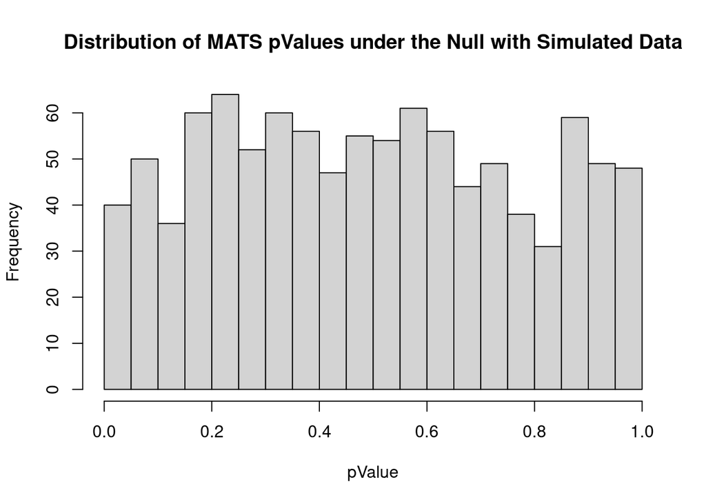

```r
pValue <- readRDS("/proj/milovelab/wu/scLDAseq/res/1MultiSample_SingleResponse_Simulation/sims1000_Manova_pValue_Null_nSample20_nCellType5_noBatch_StromalCell.rds")
pValue <- as.numeric(do.call(rbind, pValue))
hist(pValue, main = "Distribution of MATS pValues under the Null with Simulated Data", breaks = 20)
```

### Distribution on Posterior Replicates post Topic Modeling

We then assess p-value distribution under the null, post topic modeling, which add complexity to the procedure. By fitting MANOVA on the post-topic modeling datasets, we no longer observe singular covariance matrix, so both MATS and WTS will be reported.

First we plot p-Values across ALL replicates. We do observe a relative uniform distribution using all replicates (a total of 1000 $\times$ 100 p-values)

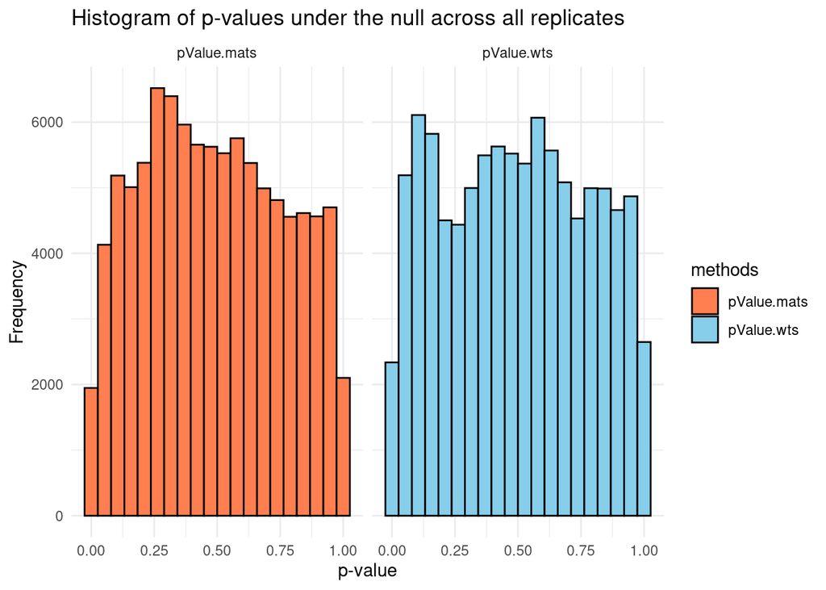

```r
pValue <- readRDS("/proj/milovelab/wu/scLDAseq/res/1MultiSample_SingleResponse_Simulation/1000ManovaTheta_Pooled_noContent_Prevalence_Time.rds")
pValue <- pValue[grep("NullModel",names(pValue))]
rep <- do.call(rbind, pValue)
rep_long <- pivot_longer(rep, cols = everything(), names_to = "methods", values_to = "pValue")
ggplot(rep_long, aes(x = pValue)) +
  geom_histogram(bins = 20, color = "black", aes(fill = methods)) +
  facet_wrap(~ methods) +
  theme_minimal() +
  labs(x = "p-value", y = "Frequency", title = "Histogram of p-values under the null across all replicates") +
  scale_fill_manual(values = c("pValue.wts" = "skyblue", "pValue.mats" = "coral"))
```

Then we pick the medium of the pValue of 100 replicates within each simulation, and re-plot the distribution. I do not observe significant effect on the distribution due to the medium.

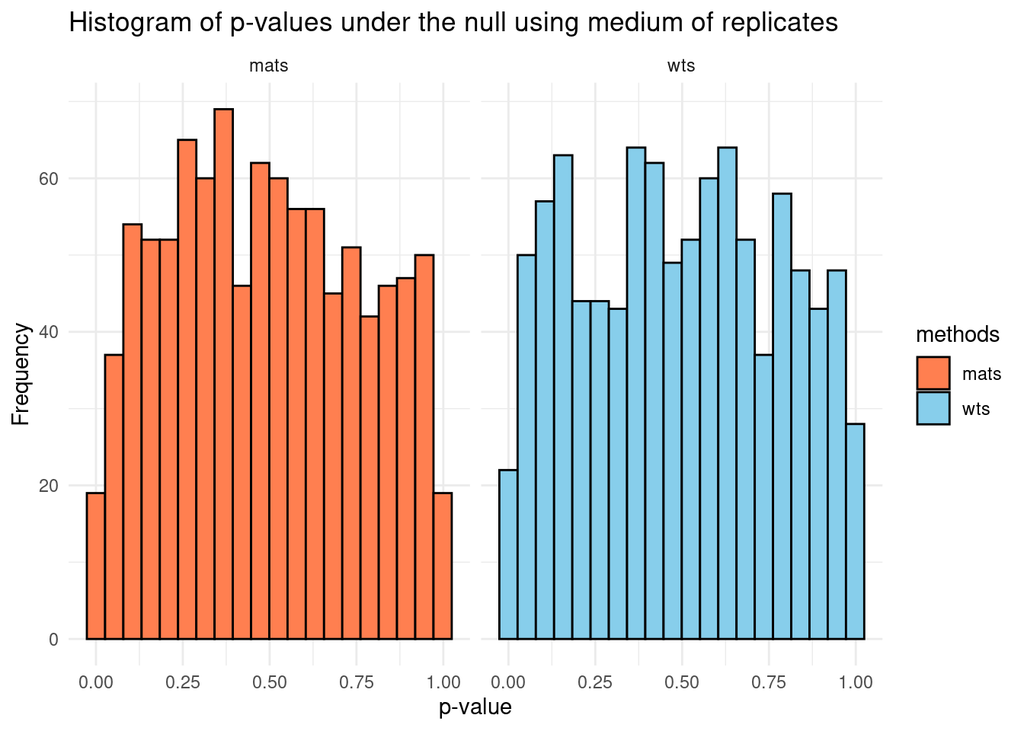

```r
manova.pValue <- lapply(pValue, function(x) {
  data.frame(wts =quantile(x$pValue.wts, probs = 0.50),
             mats = quantile(x$pValue.mats, probs = 0.50))
})
manova.pValue <- do.call(rbind, manova.pValue)
manova.pValue.long <- pivot_longer(manova.pValue, cols = everything(), names_to = "methods", values_to = "pValue")
ggplot(manova.pValue.long, aes(x = pValue)) +
  geom_histogram(bins = 20, color = "black", aes(fill = methods)) +
  facet_wrap(~ methods) +
  theme_minimal() +
  labs(x = "p-value", y = "Frequency", title = "Histogram of p-values under the null using medium of replicates") +
  scale_fill_manual(values = c("wts" = "skyblue", "mats" = "coral"))
```

Additionally, I also plotted 75th quantile, as it was another method recommended in Scott’s paper. Similar to medium, we do not observe a significant change in the distribution.

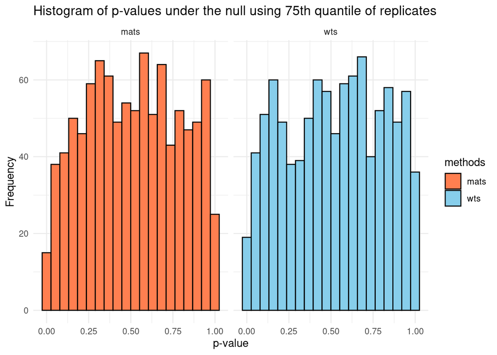

```r
manova.pValue <- lapply(pValue, function(x) {
  data.frame(wts =quantile(x$pValue.wts, probs = 0.75),
             mats = quantile(x$pValue.mats, probs = 0.75))
})
manova.pValue <- do.call(rbind, manova.pValue)
manova.pValue.long <- pivot_longer(manova.pValue, cols = everything(), names_to = "methods", values_to = "pValue")
ggplot(manova.pValue.long, aes(x = pValue)) +
  geom_histogram(bins = 20, color = "black", aes(fill = methods)) +
  facet_wrap(~ methods) +
  theme_minimal() +
  labs(x = "p-value", y = "Frequency", title = "Histogram of p-values under the null using 75th quantile of replicates") +
  scale_fill_manual(values = c("wts" = "skyblue", "mats" = "coral"))
```

### TypeI Error

Since all models are simulated under the null, we can measure the Type I error by calculating the number of rejections of the null. We can see that both MATS and WTS are performing at or under the threshold, which is our desired results.

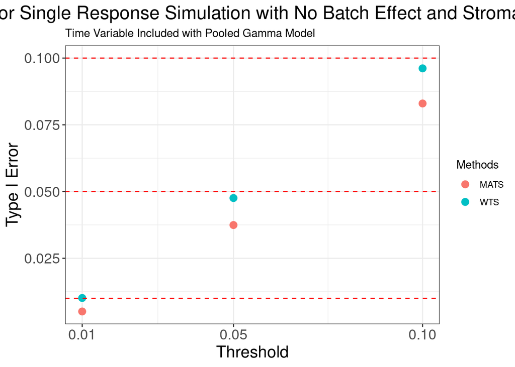

```r
threshold <- c(0.01, 0.05, 0.1)
topic_plot <- readRDS("/proj/milovelab/wu/scLDAseq/res/1MultiSample_SingleResponse_Simulation/1000sims_TypeIError.rds")
ggplot(topic_plot, aes(x = Threshold, y = TypeIError, color = Methods, group = Methods)) +
  geom_point(size = 3) +
  geom_hline(yintercept = c(0.01, 0.05, 0.1), linetype = "dashed", color = "red") +
  labs(title = "Type I Error for Single Response Simulation with No Batch Effect and Stromal Cells only",
       subtitle = "Time Variable Included with Pooled Gamma Model",
       x = "Threshold",
       y = "Type I Error") +
  theme_bw() +
  scale_x_continuous(breaks = threshold) +  # Ensure proper thresholds on X axis
  theme(
    plot.title = element_text(size = 18, hjust = 0.5),  # Increase title text size
    axis.title.x = element_text(size = 16),  # Increase X axis title size
    axis.title.y = element_text(size = 16),  # Increase Y axis title size
    axis.text.x = element_text(size = 14),   # Increase X axis labels size
    axis.text.y = element_text(size = 14)   # Increase Y axis labels size
  )
```